# Data Wrangling Final Project

## Introduction

First I need to make an introduction about the first data I will use.  
This database contains pitching, hitting, and fielding statistics for Major League Baseball from 1871 through 2018. It includes data from the two current leagues (American and National), the four other “major” leagues (American Association, Union Association, Players League, and Federal League), and the National Association of 1871-1875.  
This database was created by Sean Lahman, who pioneered the effort to make baseball statistics freely available to the general public. What started as a one man effort in 1994 has grown tremendously, and now a team of researchers have collected their efforts to make this the largest and most accurate source for baseball statistics available anywhere.  
The package contains several main tables:  
Master (people): Player names, dates of birth, death and other biographical info.  
Batting: Player statistic of act of facing the opposing pitcher and trying to produce offense for one’s team  
Pitching: A pitch is the act of throwing a baseball toward home plate to start a play.  
Fielding: The performance of each player.  
The reason that I choose this dataset because I am interested in baseball and its history. I want to explore the statistic aspect of baseball.

##facts about the People Data First we need to load the master data. I want to see the average weight and height of each year player. From the output we could tell that the average height does not vary a lot troughout years. However, the average weight does vary a lot. Even in consecutive years, for example, 1997 and 1998. The average weight has a difference about 20 pounds. And I also check the player statistic for 2019 MLB season, the average player weight is about 207 pounds. From the plot we also could see that the average height has consistently increase with a stable trend. However, the average weight jump around a lot throughout years.

| birthYear | avg_weight |
| --- | --- |
| 1994 | 199.9815 |
| 1995 | 202.9107 |
| 1996 | 197.9565 |
| 1997 | 204.5000 |
| 1998 | 185.0000 |
| NA | NA |

```
## [1] 189.4292
```

| birthYear | avg_height |
| --- | --- |
| 1994 | 73.55556 |
| 1995 | 73.60714 |
| 1996 | 73.08696 |
| 1997 | 72.80000 |
| 1998 | 73.00000 |
| NA | NA |

```
## [1] 72.59008
```

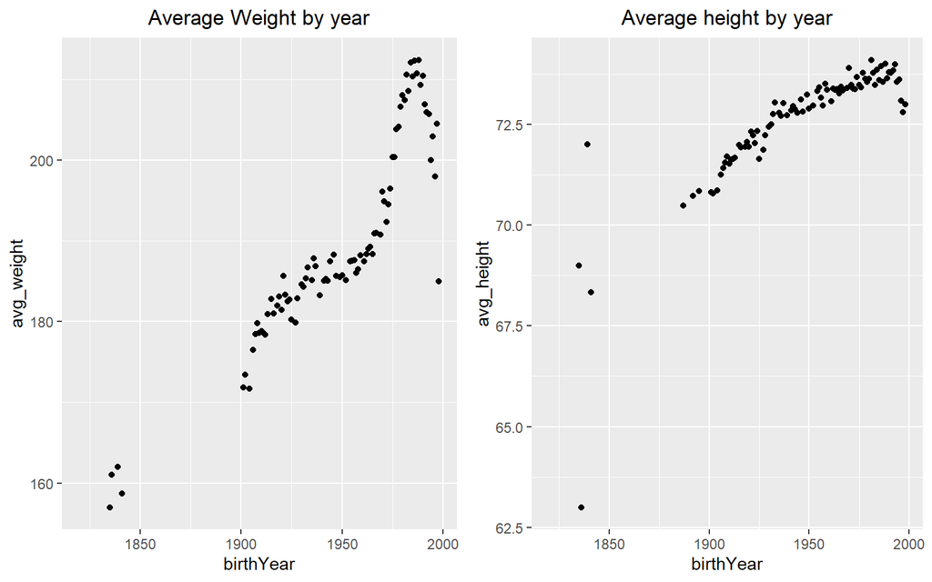

## State graph of Hall of Fame member The National Baseball Hall of Fame is a nonprofit committed to preserving the history of America’s pastime and celebrating the legendary players, managers, umpires and executives who have made the game a fan favorite for more than a century. It is a pretty meaningful organization.  
I want to explore the number of members in Hall of Fame in each state. I decide to use inner join on playerID on player and Hall of fame tables to get the players who are in the Hall. Then I find out that there is state information in college playing, using inner join on them could help me get the state information. Then I get the number of players for each state. However, while I plan to use the choropleth graph function. I realize that one important issue I have not fixed. The state name are in abbr rather than the actual name. I first try to rename each row and I know this is a stupid method. It turns out that it does not work.

Therefore, I kind of cheat here. I first export the file to CSV, and rewrite the csv file, changing the abbreviation state name into the actual name. And then I could work on the graph.

From the graph we could see the state with the most number of Hall of Fame players are California, pennsylvania, and Indiana.

| region | value |
| --- | --- |
| CA | 352 |
| PA | 185 |
| IN | 165 |
| OH | 142 |
| NY | 123 |
| IL | 102 |

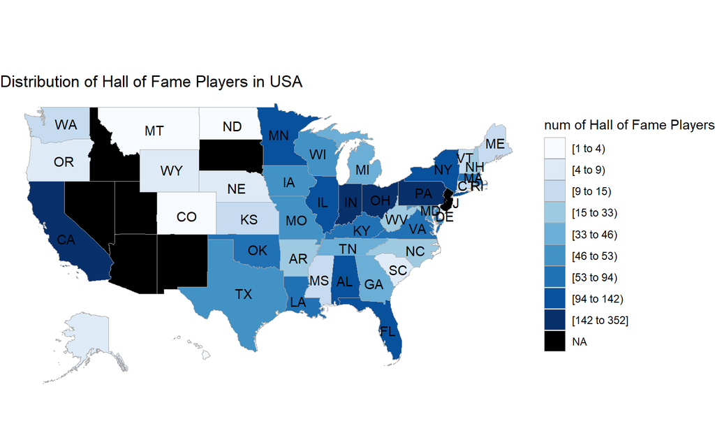

## Largest slugging percentage

|  | playerID | yearID | stint | teamID | lgID | G | AB | R | H | X2B | X3B | HR | RBI | SB | CS | BB | SO | IBB | HBP | SH | SF | GIDP |
| --- | --- | --- | --- | --- | --- | --- | --- | --- | --- | --- | --- | --- | --- | --- | --- | --- | --- | --- | --- | --- | --- | --- |
| 1 | abercda01 | 1871 | 1 | TRO | NA | 1 | 4 | 0 | 0 | 0 | 0 | 0 | 0 | 0 | 0 | 0 | 0 | NA | NA | NA | NA | 0 |
| 2 | addybo01 | 1871 | 1 | RC1 | NA | 25 | 118 | 30 | 32 | 6 | 0 | 0 | 13 | 8 | 1 | 4 | 0 | NA | NA | NA | NA | 0 |
| 3 | allisar01 | 1871 | 1 | CL1 | NA | 29 | 137 | 28 | 40 | 4 | 5 | 0 | 19 | 3 | 1 | 2 | 5 | NA | NA | NA | NA | 1 |
| 4 | allisdo01 | 1871 | 1 | WS3 | NA | 27 | 133 | 28 | 44 | 10 | 2 | 2 | 27 | 1 | 1 | 0 | 2 | NA | NA | NA | NA | 0 |
| 5 | ansonca01 | 1871 | 1 | RC1 | NA | 25 | 120 | 29 | 39 | 11 | 3 | 0 | 16 | 6 | 2 | 2 | 1 | NA | NA | NA | NA | 0 |
| 6 | armstbo01 | 1871 | 1 | FW1 | NA | 12 | 49 | 9 | 11 | 2 | 1 | 0 | 5 | 0 | 1 | 0 | 1 | NA | NA | NA | NA | 0 |

|  | playerID | birthYear | nameFirst | nameLast | SLG |
| --- | --- | --- | --- | --- | --- |
| 1 | spencsh01 | 1972 | Shane | Spencer | 0.9104478 |
| 2 | willite01 | 1918 | Ted | Williams | 0.9010989 |
| 3 | bondsba01 | 1964 | Barry | Bonds | 0.8634454 |
| 4 | ruthba01 | 1895 | Babe | Ruth | 0.8490153 |
| 5 | ruthba01 | 1895 | Babe | Ruth | 0.8462963 |
| 6 | bakerje03 | 1981 | Jeff | Baker | 0.8245614 |

```
## [1] 0.3543645
```

Above is the data in history and I want to explore the data of 2019 season.  
Comparing with the data between the history and 2019 season, we could see that the SLG score in 2019 season is much lower than the SLG score before. I think there are two reasons behind this fact:  
1. The competition of the legend has been increased from last century to 21st century. The disparity of skill among players has benn shrinked. Therefore, it is very hard to see the arise of a superstar in MLB today.  
2. The history data has been collected for a long period of time, which means that the population is very huge compared with our population in 2019 season. Therefore, it is not surprising to see some outstanding player statistic exists in a long run period of time. And we could see that the average is not that high, which proves my assumption.

|  | Rd | Pick | Player | Draft Tm | L | PA | AB | R | H | 2B | 3B | HR | TB | RBI | BB | SO | SB | CS | LOB | HR% | BB% | K% | AVG | OBP | SLG | OPS | None | None |
| --- | --- | --- | --- | --- | --- | --- | --- | --- | --- | --- | --- | --- | --- | --- | --- | --- | --- | --- | --- | --- | --- | --- | --- | --- | --- | --- | --- | --- |
| 1 | 1 | 1 | Adley Rutschman | Orioles | ALL (3) | 155 | 130 | 19 | 33 | 8 | 1 | 4 | 55 | 26 | 20 | 27 | 1 | 0 | 56 | 2.6 | 12.9 | 17.4 | 0.254 | 0.351 | 0.423 | 0.774 | NA | NA |
| 2 |  | NA |  |  |  | NA | NA | NA | NA | NA | NA | NA | NA | NA | NA | NA | NA | NA | NA | NA | NA | NA | NA | NA | NA | NA | NA | NA |
| 3 | NA | NA | NA | NA | NA | NA | NA | NA | NA | NA | NA | NA | NA | NA | NA | NA | NA | NA | NA | NA | NA | NA | NA | NA | NA | NA | NA | NA |
| 4 | 1 | 2 | Bobby Witt Jr. | Royals | ROK | 180 | 164 | 30 | 43 | 2 | 5 | 1 | 58 | 27 | 13 | 35 | 9 | 1 | 85 | 0.6 | 7.2 | 19.4 | 0.262 | 0.317 | 0.354 | 0.670 | NA | NA |
| 5 |  | NA |  |  |  | NA | NA | NA | NA | NA | NA | NA | NA | NA | NA | NA | NA | NA | NA | NA | NA | NA | NA | NA | NA | NA | NA | NA |
| 6 | NA | NA | NA | NA | NA | NA | NA | NA | NA | NA | NA | NA | NA | NA | NA | NA | NA | NA | NA | NA | NA | NA | NA | NA | NA | NA | NA | NA |

|  | Rd | Player | AVG | SLG | OPS |
| --- | --- | --- | --- | --- | --- |
| 1 | 17 | Connor Cannon | 0.324 | 0.669 | 1.063 |
| 2 | 1 | CJ Abrams | 0.393 | 0.647 | 1.083 |
| 3 | 24 | Bryce Ball | 0.329 | 0.628 | 1.023 |
| 4 | 27 | Kyle MacDonald | 0.354 | 0.604 | 1.052 |
| 5 | 30 | Jimmy Govern | 0.344 | 0.603 | 1.060 |
| 6 | 19 | Kerry Carpenter | 0.303 | 0.579 | 0.966 |

## Salary

|  | yearID | teamID | lgID | playerID | salary |
| --- | --- | --- | --- | --- | --- |
| 1 | 1985 | ATL | NL | barkele01 | 870000 |
| 2 | 1985 | ATL | NL | bedrost01 | 550000 |
| 3 | 1985 | ATL | NL | benedbr01 | 545000 |
| 4 | 1985 | ATL | NL | campri01 | 633333 |
| 5 | 1985 | ATL | NL | ceronri01 | 625000 |
| 6 | 1985 | ATL | NL | chambch01 | 800000 |

| teamID | AVG.salary | MAX.salary | MIN.salary |
| --- | --- | --- | --- |
| LAA | 4291454 | 26187500 | 316000 |
| NYA | 3968910 | 33000000 | 0 |
| BOS | 2968591 | 30000000 | 60000 |
| WAS | 2935073 | 22142857 | 316000 |
| LAN | 2795034 | 33000000 | 60000 |
| MIA | 2606827 | 19000000 | 480000 |

I also show a plot of the average and max salaries thoughout years. From the plot we could see that average salary is increasing consistently because the econnomic development, while the max salary has some bump around. This might be due to some huge baseball star arises when the peak exists.

| yearID | Avg.salary | MAX.salary | MIN.salary |
| --- | --- | --- | --- |
| 1985 | 476299.4 | 2130300 | 60000 |
| 1986 | 417147.0 | 2800000 | 60000 |
| 1987 | 434729.5 | 2127333 | 62500 |
| 1988 | 453171.1 | 2340000 | 62500 |
| 1989 | 506323.1 | 2766667 | 62500 |
| 1990 | 511973.7 | 3200000 | 100000 |

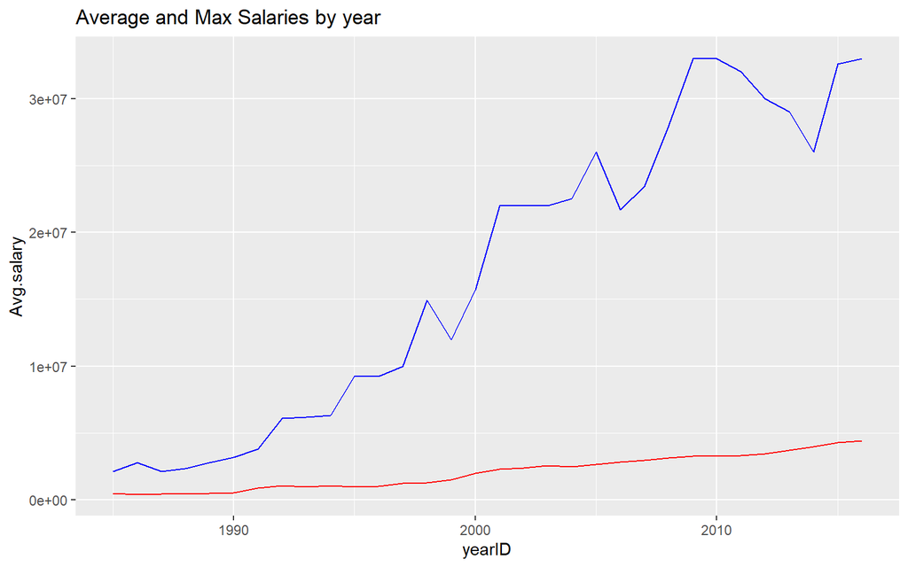

## Popular name

I also want to determine the 5 most popular first names in baseball among players. After inital try, I find out that there are too many data statistic because this is a quite large database. Therefore, we need to set some constraints on the dataset we get. Since there are many players who just played serveral games in baseball league, I decide to filter out the players who just play several games in career.  
First, I need to filter out the NA statistic in game record. Then I realized another issue that the table just records the game a player played in that single year. They do not have the games a player played in his career. Therefore, I need to first make a variable career total to sum up all the games a single player plays.

| playerID | career_total | nameFirst | nameLast | nameGiven | birthYear |
| --- | --- | --- | --- | --- | --- |
| rosepe01 | 3528 | Pete | Rose | Peter Edward | 1941 |
| aaronha01 | 3020 | Hank | Aaron | Henry Louis | 1934 |
| ripkeca01 | 2977 | Cal | Ripken | Calvin Edwin | 1960 |
| cobbty01 | 2954 | Ty | Cobb | Tyrus Raymond | 1886 |
| vizquom01 | 2940 | Omar | Vizquel | Omar Enrique | 1967 |
| mayswi01 | 2929 | Willie | Mays | Willie Howard | 1931 |

After collecting the career total games data, I am able to work out to determine the 5 most popular first names in baseball among players who played at least 500 games.

| nameFirst | count |
| --- | --- |
| Mike | 80 |
| Joe | 60 |
| John | 56 |
| Bill | 55 |
| Jim | 52 |
| Bob | 48 |
| George | 45 |
| Dave | 43 |
| Johnny | 36 |
| Jack | 34 |

[output cut: 868 more lines]

After get the name and count tables, we could see that the most popular names are Mike, Joe, John, Bill and Jim. Then I want to plot them on the same graphs.

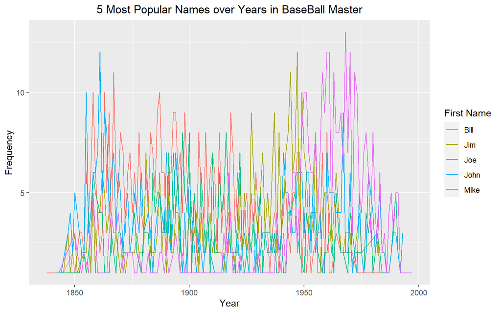

## Connect with twitter

I want to see how people are concerning with MLB baseball league during such a special period of time. Using the package rtweet could help me gather the information from twitter, you will need to authorization using your own twitter account.  
Here is the link for reference: “https://www.rdocumentation.org/packages/rtweet/versions/0.4.0”  
And in order to retain the orginal information, I filter out the retweet data.

[output not shown]

From the plot we could see that there are less and less poeple are concerning about MLB. I think this is because at this special period, with MLB has already been lockout, the information of MLB are quite not popular among people.

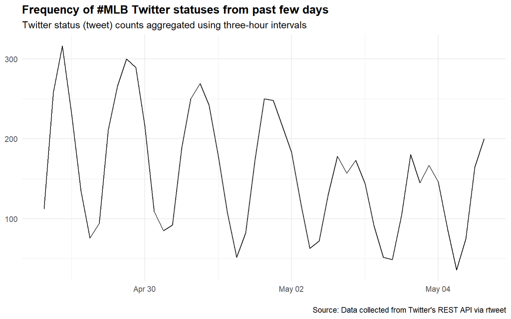

And I also want to share a note on in which state people are concerned about the MLB.  
However, I do not know if there is something wrong with my code or not. My plot contains little information. As you cansee, there are quite little information about the people who sent tweets related to MLB. And many of the states do not have any tweets related to MLB hashtag.

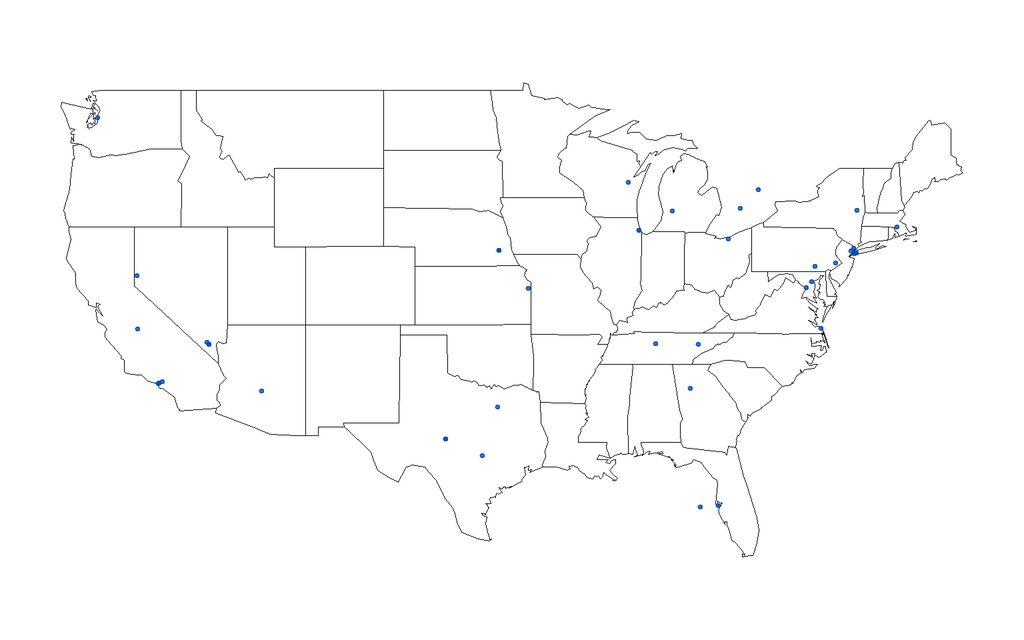

# Conclusion

I think this project is quite meaningful for me. Because I do learn a lot from this course lecture and homework. However, I do not have a time to review them in a comprehensive aspect. This project provide a chance to go over what I have learnt in this course.  
I think my project touch upon most of the stuffs covered in the class. One thing I think I do not include is regular expression part because my data does not require related method. However, I do go over the regular expression stuffs and I think I get a comprehensive understanding on it because my HW grade on it is good.  
Overall, I think this is the best course in this semester because I do learn a lot useful techinique and methods in this class and I believe that they are helpful in my future career. Thank you for your lecture!